# Chocolate Rating Project

Group 15

# Introduction

The goal of the project is to explore the elements that may influence the taste and rating of chocolate. Chocolate is a kind of sweet food made of cocoa products (including cocoa butter, cocoa powder or cocoa pulp) and sugar as the main raw materials. It tastes delicate and sweet, and accompanied by a strong aroma. It is a major category of leisure snacks. Global consumption of chocolate products reached 10.424 million tons in 2019, up 1.8 percent from 2018, and is expected to exceed 11 million tons in 2023. As one of the most popular candies around the world, we are more interested in doing research for the taste of chocolate so that we are able to enjoy delicious chocolate.

To achieve the goal of the project, we are going to use the Chocolate Bar 2020 dataset collected by Soroush Ghaderi which carries information from 2006 to 2020 in 66 countries about chocolate reviews and tastes. It contains expert ratings compiled by Brady Brelinski, who is the founding member of the Manhattan Chocolate Society, for more than 1,700 chocolate bars, as well as information on where the chocolate comes from, their cocoa percentage, the type of chocolate beans used and where the chocolate beans are grown. We will analyze the associations between the chocolate rating and the factors including cocoa percentage, ingredients and so on.

# Question of Interest

1. What creates chocolate bars with the highest ratings?
2. Which model, LDA or logistic model, performs better in classification here?

# Background

Our source of the data set is from [here](https://www.kaggle.com/soroushghaderi/chocolate-bar-2020?select=chocolate.csv).

The variables in the dataset include REF(unique number for number), Campany (Name of the company manufacturing the bar), Company_Location (The country where the company is located), ReviewDate (Date review for chocolate bar), Country_of_bean_origrin (Country of chocolate bean), Specific_Bean_Original_Bar Name (The specific province of chocolate bean),CocoaPercent (Cocoa percentage (darkness) of the chocolate bar being reviewed), Rating (Expert rating for chocolate bar), Counts_of_ingredients (Number of ingredients used), Beans/Cocoa_butter/Vanilia/Lecithin/Salt/Sugar (Whether chocolate has these ingredients or not), First/Second/Third/Fourth_taste (Taste of chocolate in different times).

The Cocoa Rating system is divided into 4 levels to tell how great the taste is:

- 3.5 ~ 4 = Highly Recommended
- 3.0 ~ 3.49 = Recommended
- 2.0 ~ 2.9 = Disappointing
- 1.0 ~ 1.9 = Unpleasant

First we will take a look at our rating scores’ distribution as shown in Figure 1. From the figure, we can observe that most of the data are distributed between 2.75 and 4, while the weight of ratings under 2.5 and beyond 4.0 is quite light. Our distribution figure indicates that on average, gourmets are satisfied with chocolates and think they are neutral and recommended.

For easier readability, we will transform our rating scores into binary variables. If the rating score is less than 3, it will be classified as 0, meaning these chocolates are unrecommended. If the rating score is greater than or equal to 3, it will be classified as 1, meaning it is recommended or even highly recommended. The distribution of binary ratings is shown in Figure 2.

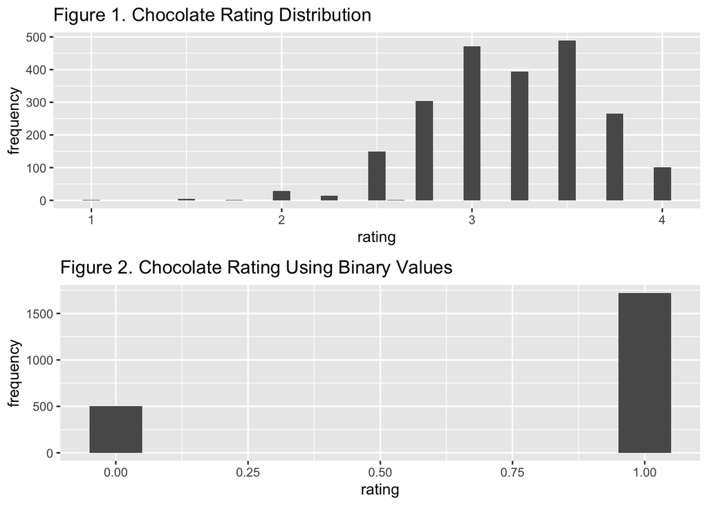

From figure 2, we can see that the proportion of high rating chocolates(binary value 1) is much higher than the low rating ones(binary value 0), which again shows that chocolates are appealing to people on average.

# Data Analysis

In this part, we will analyze our dataset in detail by focusing on the factors that influence chocolate rating as well as the relationship between chocolate rating, cocoa percent, and counts of ingredients. Time influences will also be used in order to have more precise results.

### Principal factors that may influence the rating of chocolate

For our question of interest 1, we will make an hypothesis that the `cocoa bean cocoa percent` , `ingredients counts`, and `review date` have a significant effect on the chocolate rating. To test our idea, we choose to use the `PCA` method to find the principal components.

Considering rotations of PC1, cocoa_percent and review_date are inversely related to the first principal component(which has a negative value in rotation of PC1), when the counts_of_ingredients is positively related to it.

```
##                                        PC1         PC2        PC3
## chocolate.cocoa_percent         -0.3796461  0.88675785 -0.2636843
## chocolate.counts_of_ingredients  0.6855608  0.07828211 -0.7237944
## chocolate.review_date           -0.6211886 -0.45555727 -0.6376459
```

The proportion of variance indicates how much of total variance is there in variance of a particular principal component. Hence, PC1 variability explains 47.74% of total variance of the data, when the PC2 variability explains 31.83% of total variance of the data. These first two proportion values are similar when the first proportion of variance is a bit larger.

```
## Importance of components:
##                           PC1    PC2    PC3
## Standard deviation     1.1967 0.9773 0.7828
## Proportion of Variance 0.4774 0.3183 0.2043
## Cumulative Proportion  0.4774 0.7957 1.0000
```

We can also obtain the biplot to check out the result, as shown in figure 3.

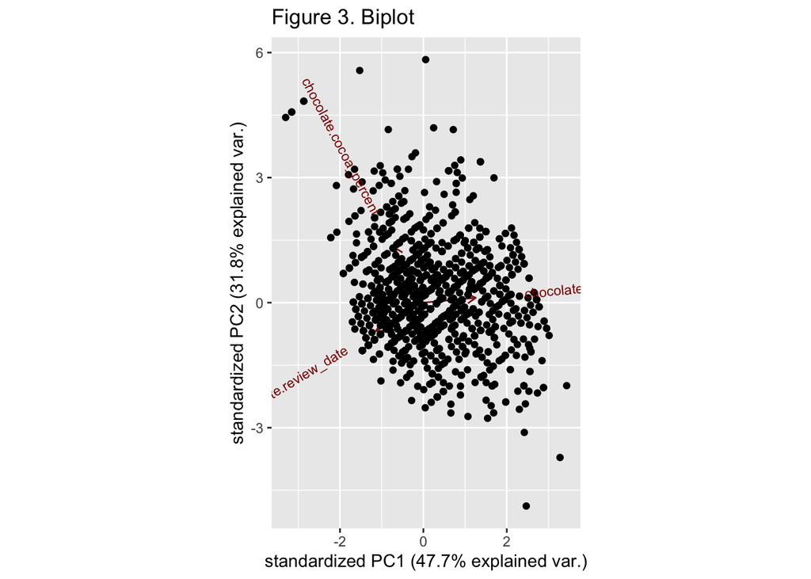

From figure 3 we can see that based on the plot of standardized PC1, we can conclude that the cocoa_percent, counts_of_ingredients and the review_date are all relatively important effects on the first principal component. And since all three vectors all have a large angle, they might not have a close relationship with each other.

#### `Association between Rating and Cocoa Percent`

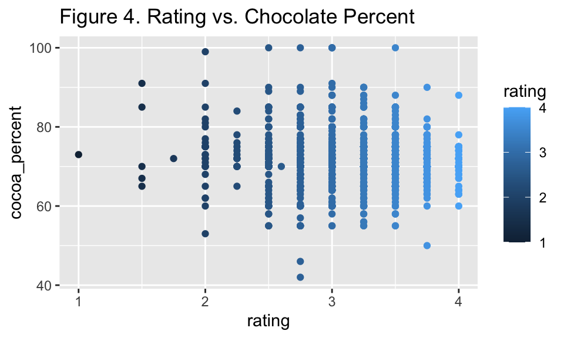

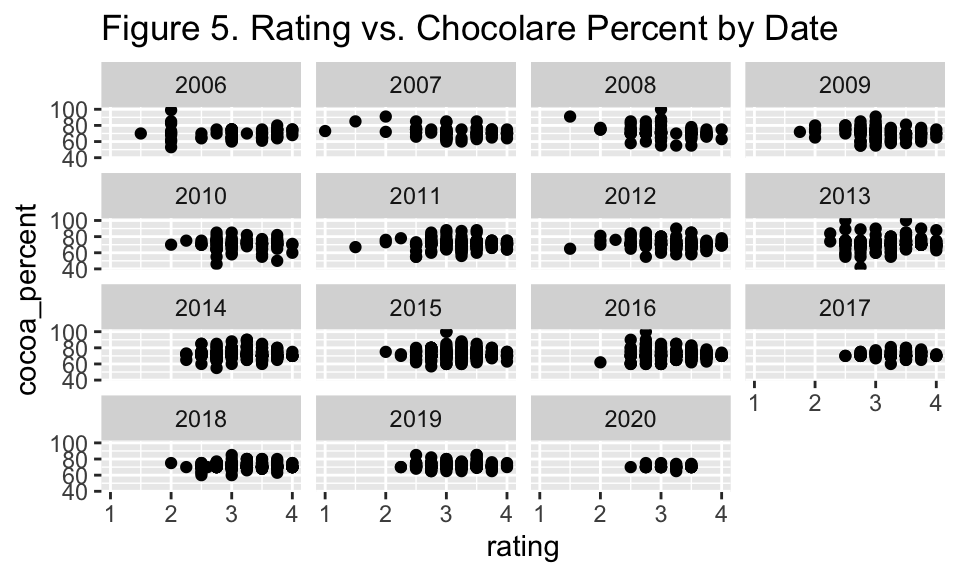

In addition, we think there might be a change of rating depending on cocoa_percent as the time goes by. With the variable reviewDate, we separated the plot into several parts depending on the year. As shown in Figure 5, we can observe that from 2006 to 2020, the cocoa percent range with high ratings is relatively stable, which is still 60% to 80%. This agrees with our previous results. Thus we will hypothesize that the favorite cocoa percent is between 60% to 80%.

To support what we observe in the previous plots, we will use cluster sampling procedure. We will split the chocolate ratings into 4 unsupervised clusters within rating score and cocoa percent.We then calculate their average rating and the corresponding average cocoa percent.

```r
#cluster--rating vs. cocoa_percent
set.seed(15)
#km_data <- chocolate_binary%>% select(c(rating,cocoa_percent))
km_data<-data.frame(chocolate_binary$rating,chocolate_binary$cocoa_percent)
km.out<-kmeans(km_data,4,nstart=100)
km.out$centers
```

```
##   chocolate_binary.rating chocolate_binary.cocoa_percent
## 1                3.138776                       62.45102
## 2                3.021186                       83.31638
## 3                3.249885                       70.25844
## 4                3.156627                       74.97590
```

Using the cluster sampling, we get the result that the cluster cocoa_percent mean of 70.25844 has the highest cluster rating mean 3.249885. And the cluster cocoa_percent mean of 62.45102 and the cluster cocoa_percent mean of 74.97590 have the cluster rating mean 3.138776 and the cluster rating mean 3.156627 respectively, which are similar. When the cocoa_percent mean reaches 83.31638, the lowest cluster mean is 3.0211865, which is the lowest rating within these 4 clusters. Therefore, we think our result supports our statement that it is more possible for the chocolate with cocoa_percent around 70% to get a higher rating of chocolate.

Also, from the distribution of the cocoa_percent bar shown in Figure 6, we can observe that the frequency of the 70% cocoa-percent is much higher than others; meanwhile, the frequency gradually declines as the percentage of cocoa goes beyond or goes down. Based on observation, we predict that the companies may notice that the chocolate of 70% cocoa rate may be acceptable to people.

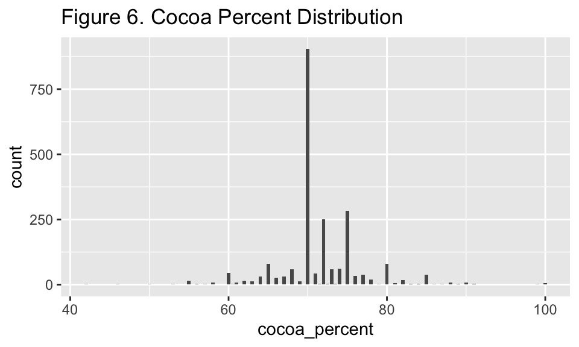

#### `Association between Ingredients and Ratings`

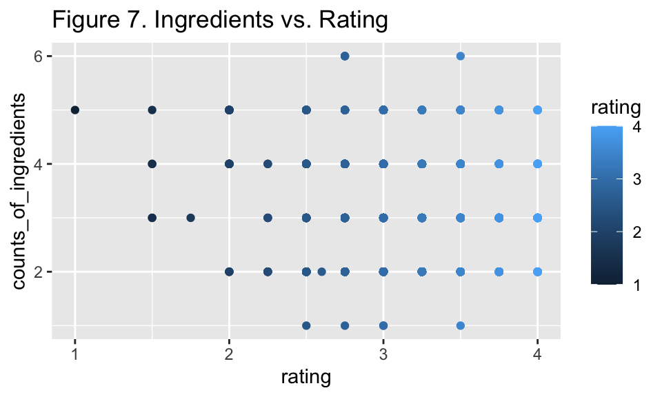

So we will choose a cluster sampling method to do more tests. Using the kmean function to randomly assign 10 unsupervised clusters

```
##    chocolate_binary.rating chocolate_binary.counts_of_ingredients
## 1                 2.443966                               5.051724
## 2                 3.385390                               3.000000
## 3                 3.344891                               5.007299
## 4                 3.386842                               1.996491
## 5                 2.829377                               3.000000
## 6                 2.801228                               1.985965
## 7                 3.331019                               4.000000
## 8                 3.825714                               3.000000
## 9                 2.565476                               4.000000
## 10                3.805000                               2.000000
```

Additionally, a change of rating depending on count_of_ingredients may appear as time goes by as well. We separate the plot into several parts depending on the count_of_ingredients with the variable reviewDate. The result is shown in Figure 8.

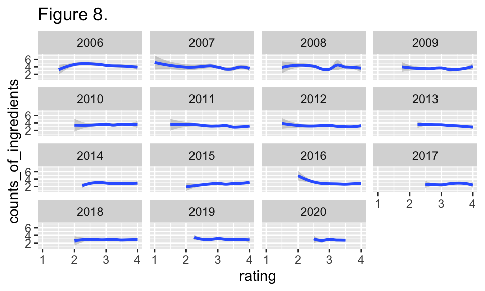

# Classification

After analyzing the cocoa percent and counts of ingredients, we will now do the classification using those two variables for prediction. We will try two different models here, the LDA model and the logistic model. We will answer our question of interest 2 here, which asks for a better classification model. Selection of the better model will be based on their accuracy. Besides, we will also find out whether both factors are necessary for classification or not.

Before we do the classification setup, we will first split the dataset with binary ratings into train data and test data with ratio 80%:20%. After splitting, the frequency of train data is:

Frequency of train data

| Var1 | Freq |
| --- | --- |
| 0 | 403 |
| 1 | 1376 |

Frequency of train data

| Var1 | Freq |
| --- | --- |
| 0 | 403 |
| 1 | 1376 |

the frequency of test data is:

| Var1 | Freq |
| --- | --- |
| 0 | 101 |
| 1 | 344 |

### LDA Model

The results of the LDA model is:

```
## Call:
## lda(factor(Rating) ~ cocoa_percent + counts_of_ingredients, data = train)
##
## Prior probabilities of groups:
##         0         1
## 0.2265318 0.7734682
##
## Group means:
##   cocoa_percent counts_of_ingredients
## 0      71.75310              3.183623
## 1      71.36919              3.040698
##
## Coefficients of linear discriminants:
##                             LD1
## cocoa_percent         -0.110344
## counts_of_ingredients -1.012864
```

By calculation, the accuracy of the LDA model is:

```
## [1] 0.7730337
```

First, we will create the LDA model with cocoa percent and counts of ingredients as predict factors, and the Rating as response factor. Through calculation, its accuracy is 0.7730337. We can see that in the LDA model, both cocoa percent and counts of ingredients are negatively correlated with ratings.

### Logistic Model

The results of the logistic model is:

```
##
## Call:  glm(formula = factor(Rating) ~ cocoa_percent + counts_of_ingredients,
##     family = binomial(link = "logit"), data = train)
##
## Coefficients:
##           (Intercept)          cocoa_percent  counts_of_ingredients
##               3.23046               -0.01996               -0.18453
##
## Degrees of Freedom: 1778 Total (i.e. Null);  1776 Residual
## Null Deviance:       1904
## Residual Deviance: 1893  AIC: 1899
```

By calculation, the accuracy of the logistic model is:

```
## [1] 0.7730337
```

By comparison, we can see that both counts of ingredients and cocoa percent have a greater influence on chocolate rating in the LDA model than in the logistic model. The two models’ accuracy, though, are the same, so we can use both models for prediction.

Besides analyzing different classification models,we will also determine whether both predictors are necessary for the purpose of classification.

We will use the p-value calculated from the logistic model to analyze the necessity of two predictors. The outcomes are:

```
##                          Estimate Std. Error   z value     Pr(>|z|)
## (Intercept)            3.23046158 0.83492089  3.869183 0.0001092007
## cocoa_percent         -0.01996154 0.01081332 -1.846014 0.0648901819
## counts_of_ingredients -0.18453364 0.06121568 -3.014483 0.0025741752
```

We can see that the p-value of cocoa percent is 0.064890, and the p-value of counts of ingredients is 0.002574. By using a significant level of 5%, we can conclude that cocoa percent is not statistically significant at this level, while counts of ingredients is statistically significant. Thus, we will conclude that count of ingredients is necessary for classification but cocoa_percent is not.

Then, we will also take a look at the model without cocoa percent:

```
##
## Call:  glm(formula = factor(Rating) ~ counts_of_ingredients, family = binomial(link = "logit"),
##     data = train)
##
## Coefficients:
##           (Intercept)  counts_of_ingredients
##                 1.735                 -0.163
##
## Degrees of Freedom: 1778 Total (i.e. Null);  1777 Residual
## Null Deviance:       1904
## Residual Deviance: 1896  AIC: 1900
```

```
## [1] 0.7730337
```

The new model’s accuracy is still 0.7730337 by calculation. Thus, it is not necessary to include cocoa_percent. We only need counts_of_ingredients in the classification which shows the same performance with the full model.

With this outcome, we will continue to analyze the influence of each ingredient.

# Ingredient Analysis

#### Beans

|  | have_bean |
| --- | --- |
| 0 | 504 |
| 1 | 1720 |

Remember that in the Background part, we have found out that the total number of 0’s and 1’s are 504 and 1720 respectively. Thus, we can conclude from the above table that all chocolate bars are made with cocoa beans. However, there are quite different types of cocoa beans, and they come from many different locations. Our next step is to find out cocoa bean origins used by chocolate companies with high average ratings.

We first find out companies that have an average rating score greater than or equal to 3.75. Those companies are:

```
##  [1] "Chocola'te"
##  [2] "Heirloom Cacao Preservation (Zokoko)"
##  [3] "Idilio (Felchlin)"
##  [4] "Kerchner"
##  [5] "Landmark (Amano)"
##  [6] "Matale"
##  [7] "Nikoa"
##  [8] "Obolo"
##  [9] "Ocelot"
## [10] "Patric"
## [11] "Timo A. Meyer"
## [12] "Utopick"
```

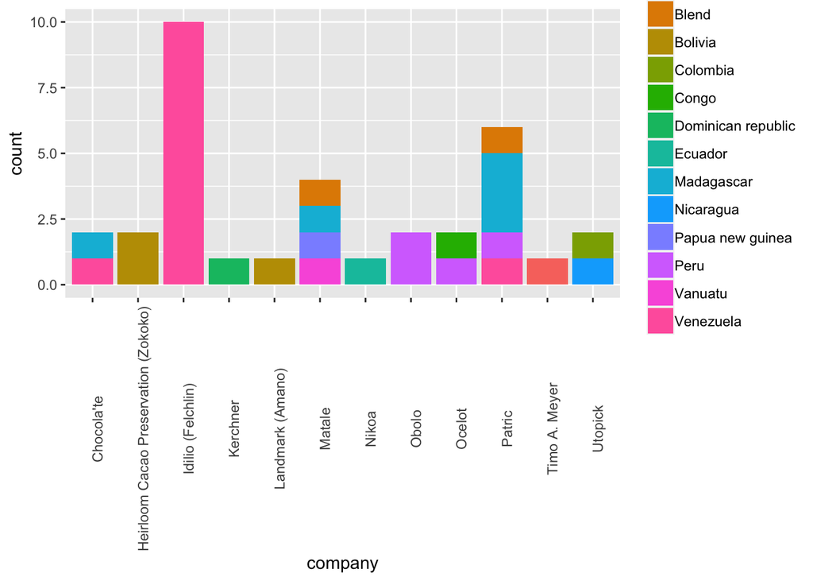

#### Other ingredients(cocoa_butter, vanilla, lecithin, salt, sugar, sweetener)

We will next use the logistic regression to the rest ingredients’ impact on chocolate bar ratings. We will choose Rating(the binary response) as our y, and all the rest ingredients as our predictors.

use logistic regression to determine each ingredients’ impact on chocolate bar ratings:

```
##                                                          (Intercept)
##                                                           0.81219970
##                   chocolate_binary$cocoa_butterhave_not_cocoa_butter
##                                                          -0.26415514
##                                  chocolate_binary$vanillahave_vanila
##                                                          -0.74081963
##                           chocolate_binary$lecithinhave_not_lecithin
##                                                           0.10278050
##                                       chocolate_binary$salthave_salt
##                                                          -0.02589142
##                                     chocolate_binary$sugarhave_sugar
##                                                           0.58137513
## chocolate_binary$sweetener_without_sugarhave_sweetener_without_sugar
##                                                          -0.07763791
```

From the glm function result we can see that the coefficient of **have not cocoa butter** is -0.26416, and the co coefficient of **have sugar** is 0.58138. This indicates that the ingredients cocoa_butter and sugar have a positive correlation with the binary Rating result, and the effectiveness of sugar is larger since the coefficient is larger.

The coefficient of **have_vanilla** is -0.74082, which is a large proportion of the negative correlation coefficient for the binary Rating result. So we can conclude that adding vanilla will reduce the rating of the chocolate.

The coefficient of **have_not_lecithin** is 0.10278, **have_salt** is -0.02589 and **have_sweetness* is -0.07764, which also has a negative correlation to the binary Rating result, but these tree coefficients are quite small, we can consider lecithin, salt and sweetness might not affect the taste experience too much maybe because those are not common flavors for chocolate choosing, only those people who wants something special will choose salt or sweetness for their chocolate.

We also analyze the chocolate taste that receives the most frequent high ratings . Since there is a great loss in our data of second_taste, third_taste, and fourth_taste data, we’ll mainly draw suggestive conclusions through data in the first taste. Here, we will use a bar plot to plot the frequency of receiving a rating of 4 for all tastes in first_taste. The results are shown in the following figure :

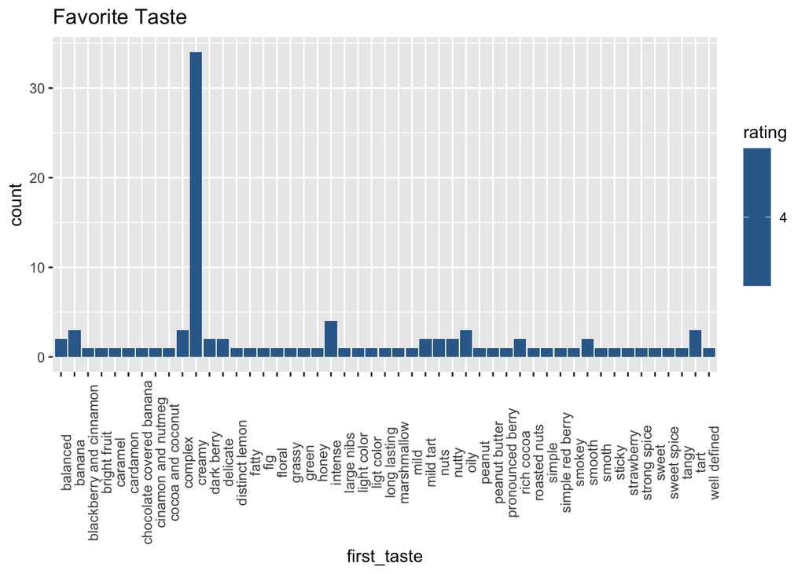

We observe that creamy taste receives much more rating of 4 than all other tastes. Thus, we can make a hypothesis that for most people, they prefer creamy-flavor chocolate, and adding cocoa_butter into the chocolate can improve the creamy concentration. The observation result is matching the taste survey. And it is also confirmed that there are less ingredients people prefer when they choose chocolate.

Best Way to Produce Chocolate Bar

| elements | method |
| --- | --- |
| cocoa butter | use cocoa butter |
| vanillar | do not use vanilla |
| lecithin | do not use lecithin |
| salt | do not use salt |
| sugar | use sugar |
| sweetener without sugar | do not use sweetner without sugar |
| count of ingredients | use three ingredients: cocoa bean, butter, and sugar |
| cocoa beans | use cocoa beans from Venezuela, Madagascar, and Peru |

Best Way to Produce Chocolate Bar

| elements | method |
| --- | --- |
| cocoa butter | use cocoa butter |
| vanillar | do not use vanilla |
| lecithin | do not use lecithin |
| salt | do not use salt |
| sugar | use sugar |
| sweetener without sugar | do not use sweetner without sugar |
| count of ingredients | use three ingredients: cocoa bean, butter, and sugar |
| cocoa beans | use cocoa beans from Venezuela, Madagascar, and Peru |

### Code Appendix

```r
knitr::opts_chunk$set(echo = FALSE)
#whitesmoke
#gainsboro
library(kableExtra)
library(ggplot2)
library(ggbiplot)
library(dplyr)
library(MASS)
library(devtools)
chocolate <- read.csv("~/Desktop/chocolate.csv")
attach(chocolate)
chocolate_binary <- chocolate
chocolate_binary$Rating <- ifelse(chocolate$rating>= 3,1,0)
#chocolate_binary$rating <- ifelse(chocolate$rating>= 3,1,0)
freq.rating <- data.frame(rating = c(1.00, 1.50, 1.75, 2.00, 2.25, 2.50,
                                    2.60, 2.75, 3.00, 3.25, 3.50, 3.75, 4.00),
                          frequency = c(length(chocolate$rating[chocolate$rating == 1]),
                                        length(chocolate$rating[chocolate$rating == 1.5]),
                                        length(chocolate$rating[chocolate$rating == 1.75]),
                                        length(chocolate$rating[chocolate$rating == 2]),
                                        length(chocolate$rating[chocolate$rating == 2.25]),
                                        length(chocolate$rating[chocolate$rating == 2.5]),
                                        length(chocolate$rating[chocolate$rating == 2.6]),
                                        length(chocolate$rating[chocolate$rating == 2.75]),
                                        length(chocolate$rating[chocolate$rating == 3]),
                                        length(chocolate$rating[chocolate$rating == 3.25]),
                                        length(chocolate$rating[chocolate$rating == 3.5]),
                                        length(chocolate$rating[chocolate$rating == 3.75]),
                                        length(chocolate$rating[chocolate$rating == 4])))


freq.rating_binary <- data.frame(rating = c(0,1),
                          frequency = c(504,1720))

Figure1 <- ggplot(freq.rating)+
  geom_col(aes(x=rating,y=frequency))+
  ggtitle("Figure 1. Chocolate Rating Distribution")

Figure2 <- ggplot(freq.rating_binary)+
  geom_col(aes(x=rating,y=frequency),width = 0.1)+
  ggtitle("Figure 2. Chocolate Rating Using Binary Values")


gridExtra::grid.arrange(Figure1,Figure2,ncol=1)
chocolate_rating <- data.frame(chocolate$cocoa_percent,
                               chocolate$counts_of_ingredients,
                               chocolate$review_date)
pr.out<-prcomp(chocolate_rating ,scale=TRUE)
pr.out$rotation
summary(pr.out)
x<- chocolate_binary %>%filter(Rating=="1")%>%dplyr::select(c(counts_of_ingredients,cocoa_percent))
#install_github("vqv/ggbiplot")
ggbiplot(pr.out)+ggtitle("Figure 3. Biplot")
#rating and cocoa_ percent
Figure4 <- ggplot(data=chocolate_binary,aes(y=rating,x=cocoa_percent,color = rating))+
  geom_point()+
  coord_flip()+
  ggtitle("Figure 4. Rating vs. Chocolate Percent")

Figure5 <- ggplot(data=chocolate_binary)+
  geom_point(aes(x=rating,y=cocoa_percent))+
  facet_wrap(~review_date)+
  ggtitle("Figure 5. Rating vs. Chocolare Percent by Date")

Figure4


Figure5
#gridExtra::grid.arrange(Figure5,Figure6,ncol=1)
#cluster--rating vs. cocoa_percent
set.seed(15)
#km_data <- chocolate_binary%>% select(c(rating,cocoa_percent))
km_data<-data.frame(chocolate_binary$rating,chocolate_binary$cocoa_percent)
km.out<-kmeans(km_data,4,nstart=100)
km.out$centers
ggplot(chocolate,aes(x=cocoa_percent))+
  geom_bar()+
  ggtitle("Figure 6. Cocoa Percent Distribution")
Figure7 <- ggplot(chocolate,aes(y=rating,x=counts_of_ingredients,color = rating)) +
  geom_point()+
  ggtitle("Figure 7. Ingredients vs. Rating")+
  coord_flip()

Figure8 <- ggplot(data=chocolate_binary)+
   geom_smooth(aes(x=rating, y=counts_of_ingredients))+
   facet_wrap(~review_date)+
   ggtitle("Figure 8. ")

Figure7
#gridExtra::grid.arrange(Figure7,Figure8,ncol=1)
set.seed(141)
#km_data2 <- chocolate_binary%>% select(c(rating,counts_of_ingredients))
km_data2 <- data.frame(chocolate_binary$rating,chocolate_binary$counts_of_ingredients)
km.out2<-kmeans(km_data2,10,nstart=100)
km.out2$centers
ggplot(data=chocolate_binary)+
   geom_smooth(aes(x=rating, y=counts_of_ingredients))+
   facet_wrap(~review_date)+
  ggtitle("Figure 8. ")
set.seed(1)

data1  <- chocolate_binary[chocolate_binary$Rating == 0, ]
data2  <- chocolate_binary[chocolate_binary$Rating == 1, ]

id <- sample(1:nrow(data1), 0.8 * nrow(data1))

data11 <- data1[id, ]
data12 <- data1[-id,]
id <- sample(1:nrow(data2), 0.8 * nrow(data2))

data21 <- data2[id, ]
data22 <- data2[-id, ]

train <- rbind(data11, data21)
test <- rbind(data12, data22)
table(train$Rating)%>%
  kbl(caption = "Frequency of train data") %>%
  kable_styling()

table(train$Rating)%>%
  kbl(caption = "Frequency of train data") %>%
  kable_classic(full_width = F, html_font = "Cambria")
table(test$Rating)%>%
  kbl() %>%
  kable_styling()
#lda model setip
lda_fit <- lda(factor(Rating) ~ cocoa_percent +  counts_of_ingredients, data = train)
lda_fit
p1 <- predict(lda_fit, test)
acc <- mean(p1$class == test$Rating)
acc
# Logistic Model

logit_fit <- glm(factor(Rating) ~ cocoa_percent + counts_of_ingredients, data = train,
                 family = binomial(link = "logit"))
logit_fit
p2 <- predict(logit_fit, test, type = "response")

acc2 <- mean(round(p2) == test$Rating)
acc2
summary(logit_fit)$coefficients
logit_fit3 <- glm(factor(Rating) ~ counts_of_ingredients , data = train,
                 family = binomial(link = "logit"))
logit_fit3
p <- predict(logit_fit3, test, type = "response")

acc3 <- mean(round(p) == test$Rating)
acc3

table(chocolate_binary$Rating, chocolate_binary$beans) %>%
  kbl() %>%
  kable_material(c("striped", "hover"))
company_rating <- chocolate %>% group_by(company) %>% filter(mean(rating) >= 3.75)
unique(company_rating$company)

df <- chocolate%>% filter(company==c("Chocola'te","Idilio (Felchlin)","Landmark (Amano)",
                                            "Nikoa","Ocelot","Timo A. Meyer",
                                            "Heirloom Cacao Preservation (Zokoko)",
                                            "Kerchner","Matale","Obolo","Patric","Utopick" ))
ggplot(company_rating,aes(x=company,fill=country_of_bean_origin))+
  geom_bar() +
  theme(axis.text.x = element_text(angle = 90))+
  theme(legend.title = element_text(size = 0.001))
glm(chocolate_binary$Rating ~ chocolate_binary$cocoa_butter
    +chocolate_binary$vanilla
    +chocolate_binary$lecithin
    +chocolate_binary$salt
    +chocolate_binary$sugar
    +chocolate_binary$sweetener_without_sugar,
    data = chocolate_binary, family = binomial)$coefficients
# TASTE

# first taste
taste1 <- chocolate %>% group_by(first_taste) %>% filter(rating == 4)
ggplot(taste1,aes(x = first_taste, fill = rating)) +
  geom_bar()+
  theme(axis.text.x = element_text(angle = 90))+
  ggtitle("Favorite Taste")

#second taste
#taste2 <- chocolate %>% group_by(second_taste) %>% filter(rating == 4)
#ggplot(taste2,aes(x = second_taste, fill = rating)) +
#  geom_bar()+
#  theme(axis.text.x = element_text(angle = 90))

#third taste
#taste3 <- chocolate %>% group_by(third_taste) %>% filter(rating == 4)
#ggplot(taste3,aes(x = third_taste, fill = rating)) +
#  geom_bar()+
# theme(axis.text.x = element_text(angle = 90))

#fourth taste
#taste4 <- chocolate %>% group_by(fourth_taste) %>% filter(rating == 4)
#ggplot(taste4,aes(x = fourth_taste, fill = rating)) +
#  geom_bar()+
#  theme(axis.text.x = element_text(angle = 90))
best_com <- data.frame(elements = c("cocoa butter",
                                       "vanillar",
                                       "lecithin",
                                       "salt",
                                       "sugar",
                                       "sweetener without sugar",
                                       "count of ingredients",
                                       "cocoa beans"),
                       method = c("use cocoa butter",
                                  "do not use vanilla",
                                  "do not use lecithin",
                                  "do not use salt",
                                  "use sugar",
                                  "do not use sweetner without sugar",
                                  "use three ingredients: cocoa bean, butter, and sugar",
                                  "use cocoa beans from Venezuela, Madagascar, and Peru"))
best_com %>%
  kbl(caption = "Best Way to Produce Chocolate Bar") %>%
  kable_material(c("striped", "hover"))
best_com%>%
  kbl(caption = "Best Way to Produce Chocolate Bar") %>%
  kable_classic(full_width = F, html_font = "Cambria")
```